# Data features

In this notebook we will look closely at the features of the dataset, how they correlate, how data is distributed.  
The data has been cleaned and some insights already gained.  
If you haven't seen the first notebook, I strongly recommend browsing through it at least briefly.  
Also the data used here is a result of processing in the first notebook, so it should be launched at least once.

The data was taken from the [official website](https://www.nyc.gov/site/tlc/about/tlc-trip-record-data.page).  
Information about the dataset:

| Field Name | Description |
| --- | --- |
| **VendorID** | A code indicating the TPEP provider that provided the record. 1 = Creative Mobile Technologies, LLC 2 = Curb Mobility, LLC 6 = Myle Technologies Inc 7 = Helix |
| **tpep_pickup_datetime** | The date and time when the meter was engaged. |
| **tpep_dropoff_datetime** | The date and time when the meter was disengaged. |
| **passenger_count** | The number of passengers in the vehicle. |
| **trip_distance** | The elapsed trip distance in miles reported by the taximeter. |
| **RatecodeID** | The final rate code in effect at the end of the trip. 1 = Standard rate 2 = JFK 3 = Newark 4 = Nassau or Westchester 5 = Negotiated fare 6 = Group ride 99 = Null/unknown |
| **store_and_fwd_flag** | This flag indicates whether the trip record was held in vehicle memory before sending to the vendor, aka "store and forward," because the vehicle did not have a connection to the server. Y = store and… |
| **PULocationID** | TLC Taxi Zone in which the taximeter was engaged. |
| **DOLocationID** | TLC Taxi Zone in which the taximeter was disengaged. |
| **payment_type** | A numeric code signifying how the passenger paid for the trip. 0 = Flex Fare trip 1 = Credit card 2 = Cash 3 = No charge 4 = Dispute 5 = Unknown 6 = Voided trip |
| **fare_amount** | The time-and-distance fare calculated by the meter. For additional information on the following columns, see https://www.nyc.gov/site/tlc/passengers/taxi-fare.page |
| **extra** | Miscellaneous extras and surcharges. |
| **mta_tax** | Tax that is automatically triggered based on the metered rate in use. |
| **tip_amount** | Tip amount – This field is automatically populated for credit card tips. Cash tips are not included. |
| **tolls_amount** | Total amount of all tolls paid in trip. |
| **improvement_surcharge** | Improvement surcharge assessed trips at the flag drop. The improvement surcharge began being levied in 2015. |
| **total_amount** | The total amount charged to passengers. Does not include cash tips. |
| **congestion_surcharge** | Total amount collected in trip for NYS congestion surcharge. |
| **airport_fee** | For pick up only at LaGuardia and John F. Kennedy Airports. |
| **cbd_congestion_fee** | Per-trip charge for MTA's Congestion Relief Zone starting Jan. 5, 2025. |

## Imports

```python
import pandas as pd
import numpy as np
import matplotlib.pyplot as plt
import matplotlib.dates as mdates
import seaborn as sns
import scipy.stats as sps
```

```python
df = pd.read_parquet('../data/processed/clean_data.parquet')
```

## Notebook settings

```python
turn_on_graphs = True  # Enable or disable graphic visuals
pd.set_option('display.max_columns', None)  # Show all columns for dataframes
```

A custom function to plot feature distributions.

```python
def plot_distribution(series, col_name, u_count = 10):
    if turn_on_graphs:
        plt.figure(figsize=(10, 6))

        is_datetime = pd.api.types.is_datetime64_any_dtype(series)
        data_no_na = series.dropna()
        unique_count = data_no_na.nunique()

        if unique_count < u_count:
            counts = series.value_counts(dropna=True).sort_index()


            if is_datetime:
                x_labels = [mdates.num2date(mdates.date2num(val)).strftime('%Y-%m-%d %H:%M:%S')
                            for val in counts.index]
            else:
                x_labels = counts.index.astype(str)

            bars = plt.bar(range(len(counts)), counts.values, tick_label=x_labels,
                           edgecolor='black', alpha=0.7)
            plt.xticks(rotation=45, ha='right')
            plt.xlabel(col_name)

            for bar, count in zip(bars, counts.values):
                height = bar.get_height()
                plt.text(bar.get_x() + bar.get_width()/2., height,
                         f'{count}', ha='center', va='bottom', fontsize=9)
        else:
            if is_datetime:
                dates_num = mdates.date2num(data_no_na.to_numpy())
                plt.hist(dates_num, bins=50, edgecolor='black', alpha=0.7)
                locator = mdates.AutoDateLocator()
                formatter = mdates.AutoDateFormatter(locator)
                plt.gca().xaxis.set_major_locator(locator)
                plt.gca().xaxis.set_major_formatter(formatter)
                plt.gcf().autofmt_xdate()
                plt.xlabel('Date/time')
            else:
                plt.hist(data_no_na, bins=50, edgecolor='black', alpha=0.7)
                plt.xlabel(col_name)

        plt.ylabel('Frequency')
        plt.title(f'Feature distribution: {col_name}')
        plt.grid(axis='y', linestyle='--', alpha=0.7)
        plt.tight_layout()
        plt.show()
    else:
        print('Graphs are turned off')
```

## Correlations

### Time modifications

First let's modify some features. Time and date in the dataset are considered one field. We'll modify them to show separately the date, the day of the week, and the time sector. We'll split the day into 48 half-hour periods, so as to narrow down the time at which a taxi could be called.

```python
(df['tpep_pickup_datetime'].dt.day != df['tpep_dropoff_datetime'].dt.day).sum()
```

```
np.int64(38852)
```

In most cases the day of pickup and dropoff is the same, so we will only create separate dropoff half-hour periods, so as to not make too many features.

```python
df['pickup_day_of_week'] = df['tpep_pickup_datetime'].dt.dayofweek + 1  # Monday - 1, Sunday - 7
df['pickup_day_n'] = df['tpep_pickup_datetime'].dt.day  # From 1 to 31
df['pickup_half_hour_n'] = (df['tpep_pickup_datetime'].dt.hour * 2 + (df['tpep_pickup_datetime'].dt.minute // 30) + 1)
df['dropoff_half_hour_n'] = (df['tpep_dropoff_datetime'].dt.hour * 2 + (df['tpep_dropoff_datetime'].dt.minute // 30) + 1)
```

Let's see how the new features are distributed.

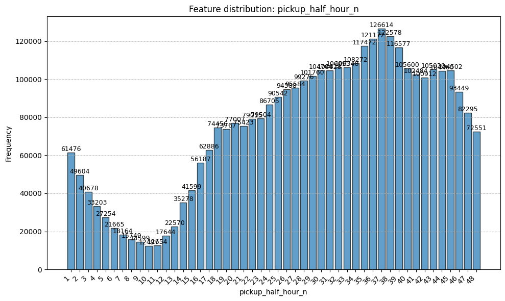

```python
plot_distribution(df['pickup_half_hour_n'], 'pickup_half_hour_n', u_count = 50)
```

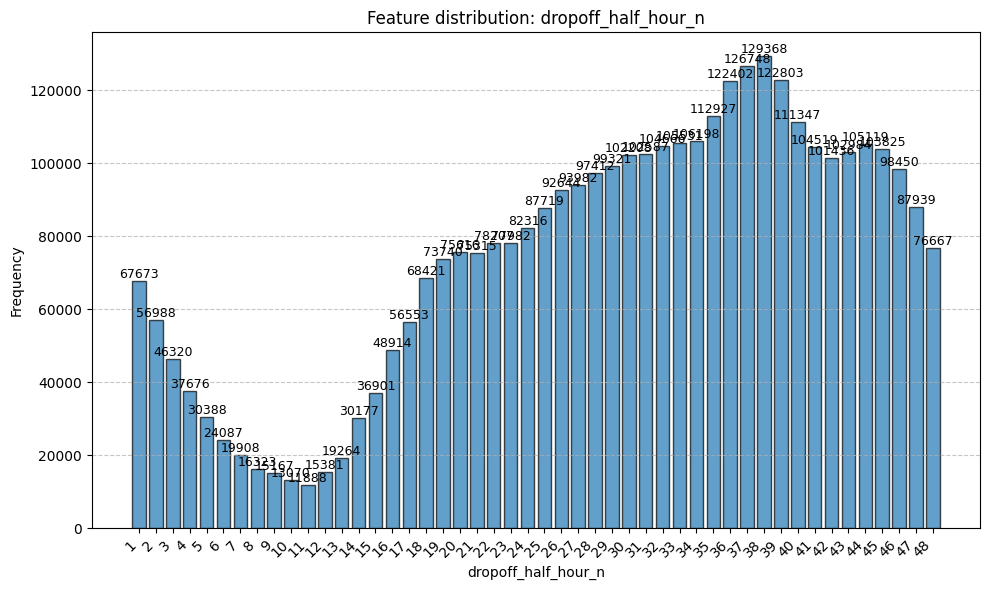

```python
plot_distribution(df['dropoff_half_hour_n'], 'dropoff_half_hour_n', u_count = 50)
```

Nothing too unusual here. The least amount of taxi calls is around 5-5:30 AM, while the peak is at about 7 PM

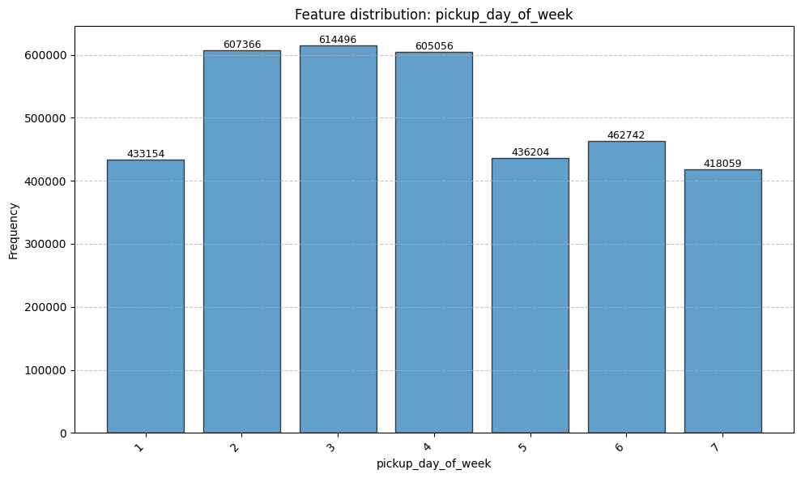

```python
plot_distribution(df['pickup_day_of_week'], 'pickup_day_of_week')
```

Tuesday, Wednesday and Thursday seem to have about 1.5 times more taxis called. That is interesting.

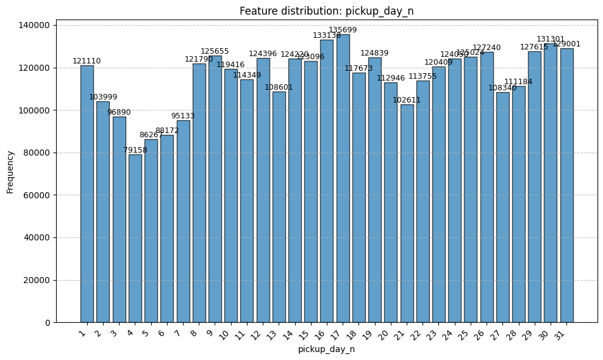

```python
plot_distribution(df['pickup_day_n'], 'pickup_day_n', u_count = 50)
```

The distribution throughout the month is roughly uniform, except for a small fall around July 4th, on which Americans celebrate Independence Day.  
No surprises here.

### Heatmap

Let's review how different features are correlated, using a heatmap.

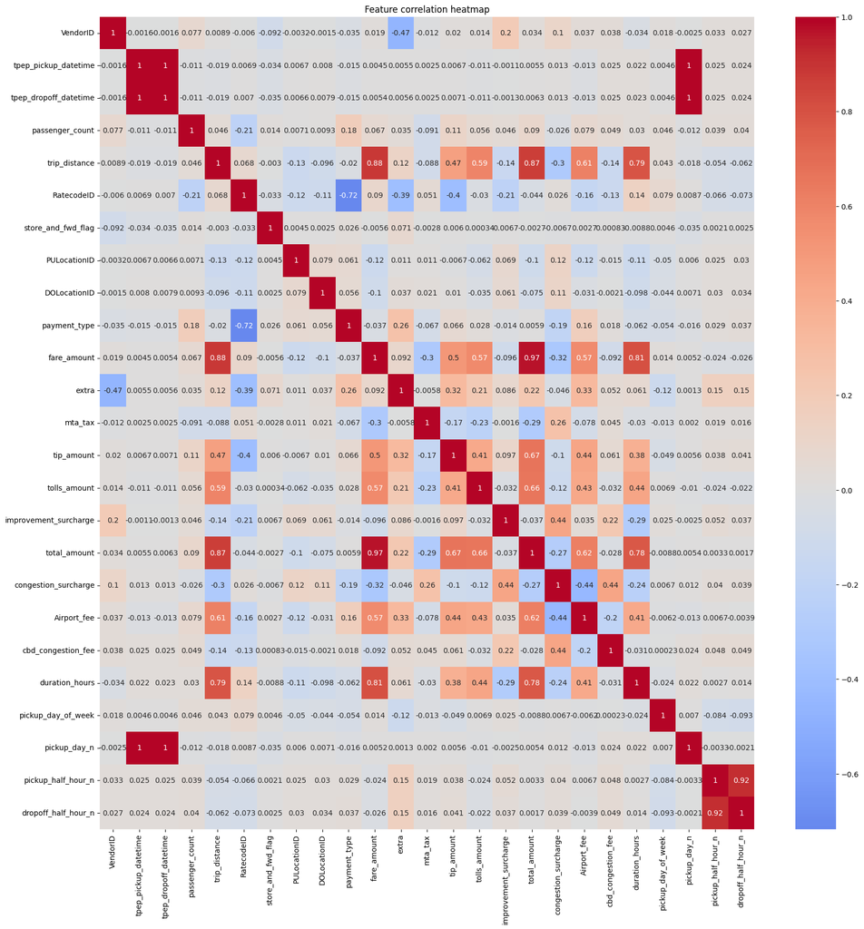

```python
corr_matrix = df.corr()

if turn_on_graphs:
    plt.figure(figsize=(20, 20))
    sns.heatmap(corr_matrix, annot=True, cmap='coolwarm', center=0)
    plt.title('Feature correlation heatmap')
    plt.show()
```

The correlations between pickup day and pickup/dropoff daytime are obvious, as are with pickup time and dropoff time (halfhour periods).

Let's see how extra is connected with the time of day when pickup or dropoff occurs.

A function to build scatter plots of two features:

```python
def plot_distribution(data, colname1, colname2):
    if turn_on_graphs:
        plt.figure(figsize=(10, 10))
        sns.scatterplot(x = data[colname1], y = data[colname2])
        plt.title(f'Feature scatterplot: {colname1}, {colname2}')
        plt.grid(alpha=0.7)
        plt.tight_layout()
        plt.show()
    else:
        print('Graphs are turned off')
```

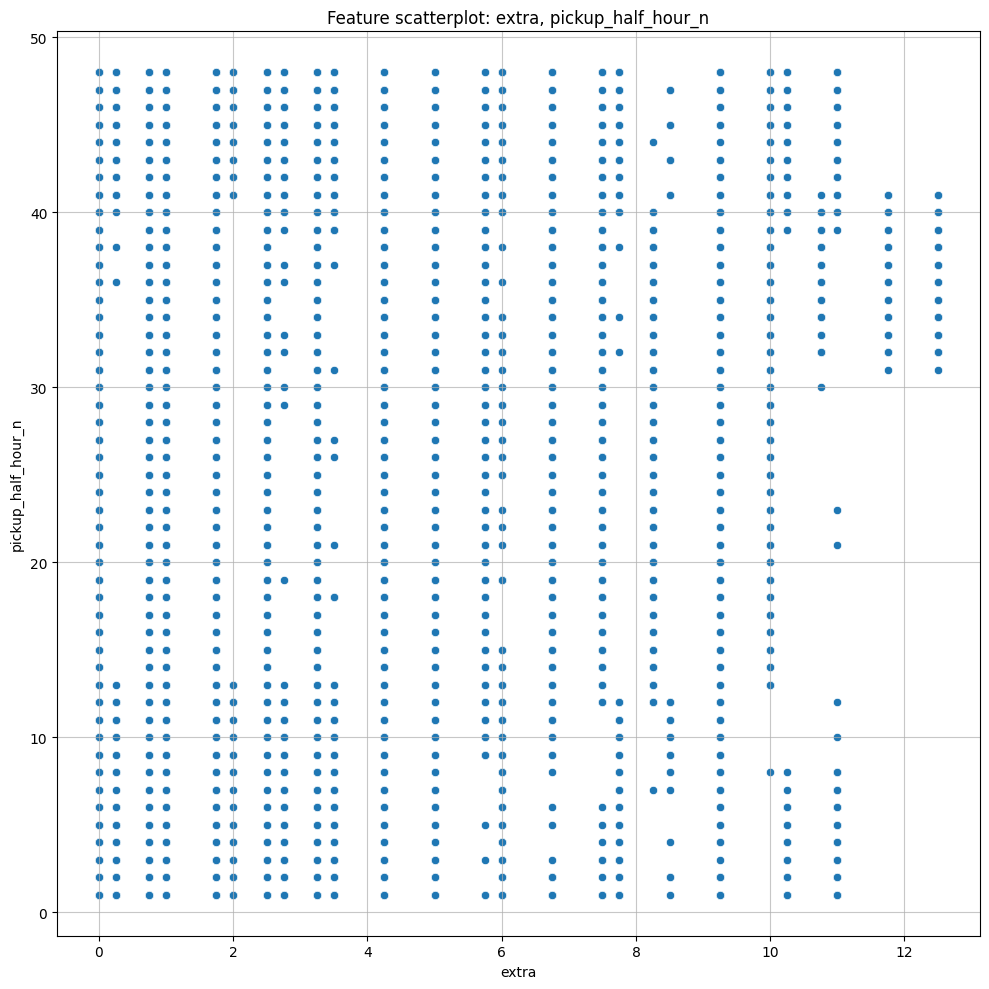

```python
plot_distribution(df, 'extra', 'pickup_half_hour_n')
```

```python
np.unique(df['extra'])
```

```
array([ 0.  ,  0.25,  0.75,  1.  ,  1.75,  2.  ,  2.5 ,  2.75,  3.25,
        3.5 ,  4.25,  5.  ,  5.75,  6.  ,  6.75,  7.5 ,  7.75,  8.25,
        8.5 ,  9.25, 10.  , 10.25, 10.75, 11.  , 11.75, 12.5 ])
```

Seems that values 11.75 and 12.5 occur only in the evening. Let's review the correlation more clearly.

```python
np.unique(df[df['extra'].isin([11.75, 12.5])]['pickup_half_hour_n'])
```

```
array([31, 32, 33, 34, 35, 36, 37, 38, 39, 40, 41], dtype=int32)
```

Let's see if the dropoff situation is the same

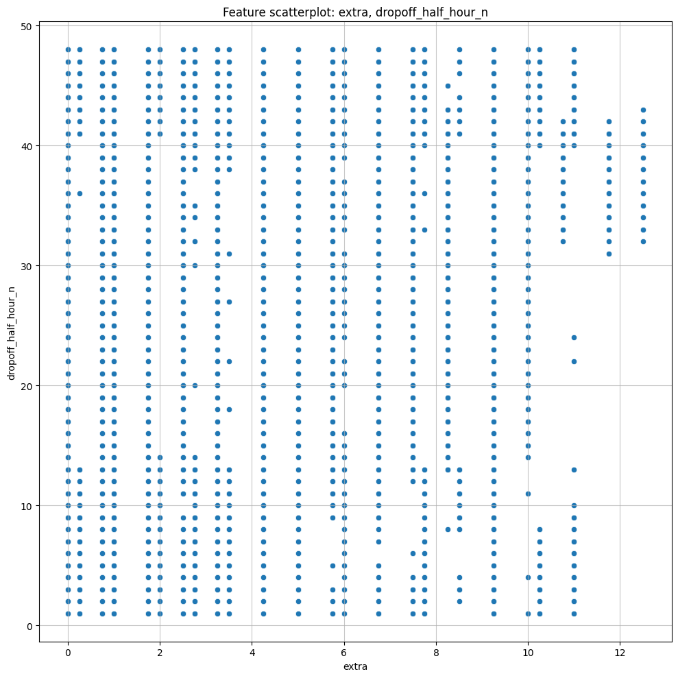

```python
plot_distribution(df, 'extra', 'dropoff_half_hour_n')
```

As expected, dropoff time of the day has a similar connection to extra.

Now let's remove features that don't seem to correlate with others and dropoff, pickup time of day (since we already examined them) and take a closer look. We'll remove: 'tpep_pickup_datetime', 'tpep_dropoff_datetime', 'store_and_fwd_flag', , 'pickup_day_of_week', 'pickup_day_n', 'pickup_half_hour_n', 'dropoff_half_hour_n'

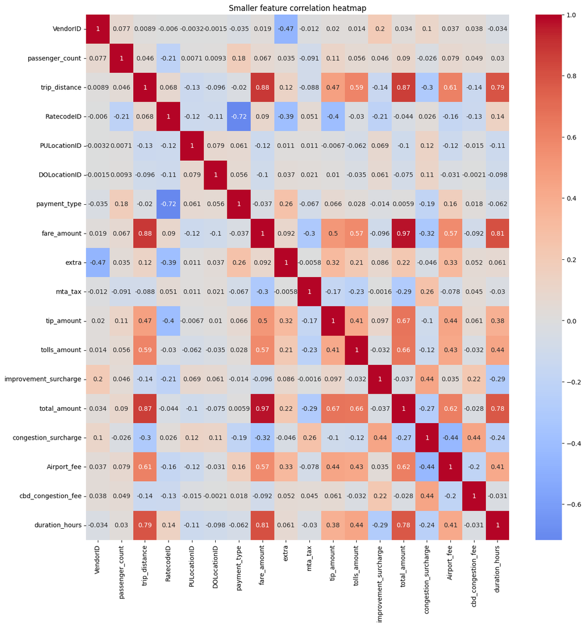

```python
cols = ['VendorID', 'passenger_count', 'trip_distance', 'RatecodeID',
       'PULocationID', 'DOLocationID', 'payment_type', 'fare_amount', 'extra',
       'mta_tax', 'tip_amount', 'tolls_amount', 'improvement_surcharge',
       'total_amount', 'congestion_surcharge', 'Airport_fee',
       'cbd_congestion_fee', 'duration_hours']

corr_matrix = df[cols].corr()

if turn_on_graphs:
    plt.figure(figsize=(15, 15))
    sns.heatmap(corr_matrix, annot=True, cmap='coolwarm', center=0)
    plt.title('Smaller feature correlation heatmap')
    plt.show()
```

Total amount and fare amount seem to be correlated quite well, which is not a big surprise, as the fare takes up the most of the total amount paid.  
Let's examine the connection.

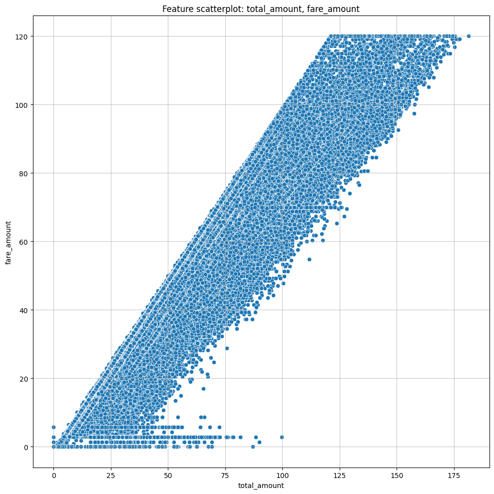

```python
plot_distribution(df, 'total_amount', 'fare_amount')
```

Something is a bit unusual with lower fares. How can the total amount be less than the fare amount?  
There are some rides with large total amount and little fare. Let's investigate.